# Assignment1-Chopde-Unhealthy vs Healthy Snack Substitution

Sylvia Satish Chopde

2022-03-09

##### **Background:**

This data source was taken from the USDA website. There are two datasets that have been used here. One is related to impact on food calories when Unhealthy snacks are substituted with Healthy snacks. The other is related to impact on cost when Unhealthy snacks are substituted with Healthy snacks.

##### **Data Sources:**

[Calorie Impact Sheet](https://www.ers.usda.gov/webdocs/DataFiles/51035/caloricimpacts.xls?v=0)  
[Cost Impact Sheet](https://www.ers.usda.gov/webdocs/DataFiles/51035/costimpacts.xls?v=0)

##### **Variable Description:**

*Calorie Impact Sheet:*  
* The first column contains a list of Unhealthy Snacks.  
* Rest of the columns have different Healthy Snack as headers and the values in each cell are the calorie impact.

*Cost Impact Sheet:*  
* The first column contains a list of Unhealthy Snacks.  
* Rest of the columns have different Healthy Snack as headers and the values in each cell are the cost impact.

Loading the required Libraries. Reading the two excel caloricimpacts.xls and costimpacts.xls and storing it as Data frames.

```r
library(tidyverse)
library(ggthemes)
library(kableExtra)
library(ggplot2)
library("readxl")
Calorie_df <- read.delim("Assignment1-Chopde-Unhealthy vs Healthy Snack Substitution_calorie.csv",header = TRUE, stringsAsFactors = FALSE, sep = ",",skip = 1)

Cost_df <- read.delim("Assignment1-Chopde-Unhealthy vs Healthy Snack Substitution_cost.csv",header = TRUE, stringsAsFactors = FALSE, sep = ",",skip = 1)

knitr::opts_chunk$set(echo = TRUE)
```

##### **CALORIE IMPACT DATA:**

```r
head(Calorie_df) %>% knitr::kable() %>% kable_styling(bootstrap_options = c("striped", "hover", "condensed","responsive")) %>% scroll_box(width="100%",height="300px")
```

| X | X.1 | Apples | Applesauce..sweetened. | Bananas | Cantaloupe | Fruit.cocktail..in.light.syrup. | Grapes | Oranges | Peaches..in.light.syrup. | Pineapple..juice.pack. | Plums | Raisins | Strawberries | Tangerine | Watermelon | Broccoli | Carrots | Celery | Red.Peppers | Sweet.potatoes | Tomatoes | Average.change.in.calories.of.replacing.each.snack.with.all.fruits.and.vegetables | X.2 |
| --- | --- | --- | --- | --- | --- | --- | --- | --- | --- | --- | --- | --- | --- | --- | --- | --- | --- | --- | --- | --- | --- | --- | --- |
|  | Calories/ portion | 77 | 100 | 102 | 33 | 71 | 59 | 53 | 68 | 75 | 38 | 109 | 27 | 72 | 74 | 12 | 22 | 10 | 23 | 90 | 16 | NA | NA |
| Chocolate candy (milk chocolate candies) | 262 | 185 | 162 | 160 | 229 | 191 | 203 | 209 | 194 | 187 | 224 | 153 | 235 | 190 | 188 | 250 | 240 | 252 | 239 | 172 | 246 | 205 | NA |
| Cookies (chocolate chip, soft) | 123 | 46 | 23 | 21 | 90 | 52 | 64 | 70 | 55 | 48 | 85 | 14 | 96 | 51 | 49 | 111 | 101 | 113 | 100 | 33 | 107 | 66 | NA |
| Corn chips | 140 | 63 | 40 | 38 | 107 | 69 | 81 | 87 | 72 | 65 | 102 | 31 | 113 | 68 | 66 | 128 | 118 | 130 | 117 | 50 | 124 | 83 | NA |
| Crackers (wheat) | 114 | 37 | 14 | 12 | 81 | 43 | 55 | 61 | 46 | 39 | 76 | 5 | 87 | 42 | 40 | 102 | 92 | 104 | 91 | 24 | 98 | 57 | NA |
| Cupcakes (chocolate, with low-fat frosting) | 174 | 97 | 74 | 72 | 141 | 103 | 115 | 121 | 106 | 99 | 136 | 65 | 147 | 102 | 100 | 162 | 152 | 164 | 151 | 84 | 158 | 117 | NA |

*Note: A negative sign indicates that calories increase when a unhealthy snack is replaced with healthy snack.*

##### **COST IMPACT DATA:**

```r
head(Cost_df) %>% knitr::kable() %>% kable_styling(bootstrap_options = c("striped", "hover", "condensed","responsive")) %>% scroll_box(width="100%",height="300px")
```

| X | X.1 | Apples | Applesauce..jarred | Bananas | Cantaloupe | Fruit.cocktail..canned | Grapes | Oranges | Peaches..canned | Pineapple..canned | Plums | Raisins | Strawberries | Tangerine | Watermelon | Broccoli | Carrots | Celery | Red.peppers | Sweet.potatoes..cooked | Tomatoes..grape.or.cherry | Total.cost.of.replacing.each.snack.with.all.fruits.and.vegetables | X.2 | X.3 | X.4 | X.5 | X.6 | X.7 | X.8 | … |
| --- | --- | --- | --- | --- | --- | --- | --- | --- | --- | --- | --- | --- | --- | --- | --- | --- | --- | --- | --- | --- | --- | --- | --- | --- | --- | --- | --- | --- | --- | --- |
|  | price/portion | 0.36 | 0.22 | 0.18 | 0.38 | 0.31 | 0.32 | 0.20 | 0.31 | 0.26 | 0.25 | 0.19 | 0.41 | 0.51 | 0.25 | 0.18 | 0.19 | 0.16 | 0.60 | 0.33 | 0.55 | NA | NA | NA | NA | NA | NA | NA | NA | … |
| Chocolate candy | 0.24 | -0.12 | 0.02 | 0.06 | -0.14 | -0.07 | -0.08 | 0.04 | -0.07 | -0.02 | -0.01 | 0.05 | -0.17 | -0.27 | -0.01 | 0.06 | 0.05 | 0.08 | -0.36 | -0.09 | -0.31 | -1.36 | NA | NA | NA | NA | NA | NA | NA | … |
| Cookies | 0.16 | -0.20 | -0.06 | -0.02 | -0.22 | -0.15 | -0.16 | -0.04 | -0.15 | -0.10 | -0.09 | -0.03 | -0.25 | -0.35 | -0.09 | -0.02 | -0.03 | 0.00 | -0.44 | -0.17 | -0.39 | -2.96 | NA | NA | NA | NA | NA | NA | NA | … |
| Corn chips | 0.21 | -0.15 | -0.01 | 0.03 | -0.17 | -0.10 | -0.11 | 0.01 | -0.10 | -0.05 | -0.04 | 0.02 | -0.20 | -0.30 | -0.04 | 0.03 | 0.02 | 0.05 | -0.39 | -0.12 | -0.34 | -1.96 | NA | NA | NA | NA | NA | NA | NA | … |
| Crackers | 0.16 | -0.20 | -0.06 | -0.02 | -0.22 | -0.15 | -0.16 | -0.04 | -0.15 | -0.10 | -0.09 | -0.03 | -0.25 | -0.35 | -0.09 | -0.02 | -0.03 | 0.00 | -0.44 | -0.17 | -0.39 | -2.96 | NA | NA | NA | NA | NA | NA | NA | … |
| Cupcakes | 0.34 | -0.02 | 0.12 | 0.16 | -0.04 | 0.03 | 0.02 | 0.14 | 0.03 | 0.08 | 0.09 | 0.15 | -0.07 | -0.17 | 0.09 | 0.16 | 0.15 | 0.18 | -0.26 | 0.01 | -0.21 | 0.64 | NA | NA | NA | NA | NA | NA | NA | … |

*Note: A negative sign indicates that food cost increases when a unhealthy snack is replaced with healthy snack.*

#### **Clean up Data Set:**

As we observed in above data frames, the data set is extremely untidy and very difficult to read. All Healthy snacks are spread across multiple columns and have separate columns names and calories value are spread across multiple rows as values. Unhealthy snacks are present without a significant column name.  
We need to gather all healthy snack under one column and all calorie value under one column. We also need to drop certain columns and rows which have incomplete data and rename a few columns.

##### Clean up the unnecessary rows based on Blank 1st column and remove unnecessary columns in Calorie Impact Data frame:

```r
Calorie_df <- Calorie_df %>% filter(X != "" & X.1 != "")
#Remove unnecessary columns in Calorie Impact Data frame
Calorie_df <- Calorie_df %>% select(-X.1, -X.2)
Calorie_df <- Calorie_df %>% select(-contains("Average"))
#Rename the first column in Calorie Impact Data frame
names(Calorie_df)[1] <- "Unhealthy_Snack"

Calorie_df %>% kable() %>% kable_styling(bootstrap_options = c("striped", "hover", "condensed", "responsive")) %>% scroll_box(width="100%",height="300px")
```

| Unhealthy_Snack | Apples | Applesauce..sweetened. | Bananas | Cantaloupe | Fruit.cocktail..in.light.syrup. | Grapes | Oranges | Peaches..in.light.syrup. | Pineapple..juice.pack. | Plums | Raisins | Strawberries | Tangerine | Watermelon | Broccoli | Carrots | Celery | Red.Peppers | Sweet.potatoes | Tomatoes |
| --- | --- | --- | --- | --- | --- | --- | --- | --- | --- | --- | --- | --- | --- | --- | --- | --- | --- | --- | --- | --- |
| Chocolate candy (milk chocolate candies) | 185 | 162 | 160 | 229 | 191 | 203 | 209 | 194 | 187 | 224 | 153 | 235 | 190 | 188 | 250 | 240 | 252 | 239 | 172 | 246 |
| Cookies (chocolate chip, soft) | 46 | 23 | 21 | 90 | 52 | 64 | 70 | 55 | 48 | 85 | 14 | 96 | 51 | 49 | 111 | 101 | 113 | 100 | 33 | 107 |
| Corn chips | 63 | 40 | 38 | 107 | 69 | 81 | 87 | 72 | 65 | 102 | 31 | 113 | 68 | 66 | 128 | 118 | 130 | 117 | 50 | 124 |
| Crackers (wheat) | 37 | 14 | 12 | 81 | 43 | 55 | 61 | 46 | 39 | 76 | 5 | 87 | 42 | 40 | 102 | 92 | 104 | 91 | 24 | 98 |
| Cupcakes (chocolate, with low-fat frosting) | 97 | 74 | 72 | 141 | 103 | 115 | 121 | 106 | 99 | 136 | 65 | 147 | 102 | 100 | 162 | 152 | 164 | 151 | 84 | 158 |
| Danish (with fruit) | 194 | 171 | 169 | 238 | 200 | 212 | 218 | 203 | 196 | 233 | 162 | 244 | 199 | 197 | 259 | 249 | 261 | 248 | 181 | 255 |
| Donuts (yeast-leavened, glazed) | 158 | 135 | 133 | 202 | 164 | 176 | 182 | 167 | 160 | 197 | 126 | 208 | 163 | 161 | 223 | 213 | 225 | 212 | 145 | 219 |
| Fruit rolls | 5 | -18 | -20 | 49 | 11 | 23 | 29 | 14 | 7 | 44 | -27 | 55 | 10 | 8 | 70 | 60 | 72 | 59 | -8 | 66 |
| Graham crackers | 25 | 2 | 0 | 69 | 31 | 43 | 49 | 34 | 27 | 64 | -7 | 75 | 30 | 28 | 90 | 80 | 92 | 79 | 12 | 86 |
| Granola bars (oats, fruit, and nut) | 42 | 19 | 17 | 86 | 48 | 60 | 66 | 51 | 44 | 81 | 10 | 92 | 47 | 45 | 107 | 97 | 109 | 96 | 29 | 103 |
| Ice cream (vanilla, light) | 119 | 96 | 94 | 163 | 125 | 137 | 143 | 128 | 121 | 158 | 87 | 169 | 124 | 122 | 184 | 174 | 186 | 173 | 106 | 180 |
| Muffins (blueberry) | 292 | 269 | 267 | 336 | 298 | 310 | 316 | 301 | 294 | 331 | 260 | 342 | 297 | 295 | 357 | 347 | 359 | 346 | 279 | 353 |
| Pizza, from frozen (cheese, regular crust) | 175 | 152 | 150 | 219 | 181 | 193 | 199 | 184 | 177 | 214 | 143 | 225 | 180 | 178 | 240 | 230 | 242 | 229 | 162 | 236 |
| Popsicles and bars (fruit/juice bars) | 3 | -20 | -22 | 47 | 9 | 21 | 27 | 12 | 5 | 42 | -29 | 53 | 8 | 6 | 68 | 58 | 70 | 57 | -10 | 64 |
| Potato chips (plain, salted) | 92 | 69 | 67 | 136 | 98 | 110 | 116 | 101 | 94 | 131 | 60 | 142 | 97 | 95 | 157 | 147 | 159 | 146 | 79 | 153 |
| Pretzels (hard, plain, salted) | 91 | 68 | 66 | 135 | 97 | 109 | 115 | 100 | 93 | 130 | 59 | 141 | 96 | 94 | 156 | 146 | 158 | 145 | 78 | 152 |
| Pudding, ready-to-eat (vanilla) | 75 | 52 | 50 | 119 | 81 | 93 | 99 | 84 | 77 | 114 | 43 | 125 | 80 | 78 | 140 | 130 | 142 | 129 | 62 | 136 |
| Sandwich crackers (rye with cheese filling) | 106 | 83 | 81 | 150 | 112 | 124 | 130 | 115 | 108 | 145 | 74 | 156 | 111 | 109 | 171 | 161 | 173 | 160 | 93 | 167 |
| Toaster pastries (fruit frosted) | 222 | 199 | 197 | 266 | 228 | 240 | 246 | 231 | 224 | 261 | 190 | 272 | 227 | 225 | 287 | 277 | 289 | 276 | 209 | 283 |
| Tortilla chips (white) | 84 | 61 | 59 | 128 | 90 | 102 | 108 | 93 | 86 | 123 | 52 | 134 | 89 | 87 | 149 | 139 | 151 | 138 | 71 | 145 |

##### Clean up the unnecessary rows based on Blank 1st column and remove unnecessary columns in Cost Impact Data frame:

```r
Cost_df <- Cost_df %>% filter(X != "" & X.1 != "")
# Remove unnecessary columns in Cost Impact Data frame
Cost_df <- Cost_df %>% select(-contains("X."))
Cost_df <- Cost_df %>% select(-contains("Total"))
#Rename the first column in Cost Impact Data frame
names(Cost_df)[1] <- "Unhealthy_Snack"


Cost_df %>% kable() %>% kable_styling(bootstrap_options = c("striped", "hover", "condensed", "responsive")) %>% scroll_box(width="100%",height="300px")
```

| Unhealthy_Snack | Apples | Applesauce..jarred | Bananas | Cantaloupe | Fruit.cocktail..canned | Grapes | Oranges | Peaches..canned | Pineapple..canned | Plums | Raisins | Strawberries | Tangerine | Watermelon | Broccoli | Carrots | Celery | Red.peppers | Sweet.potatoes..cooked | Tomatoes..grape.or.cherry |
| --- | --- | --- | --- | --- | --- | --- | --- | --- | --- | --- | --- | --- | --- | --- | --- | --- | --- | --- | --- | --- |
| Chocolate candy | -0.12 | 0.02 | 0.06 | -0.14 | -0.07 | -0.08 | 0.04 | -0.07 | -0.02 | -0.01 | 0.05 | -0.17 | -0.27 | -0.01 | 0.06 | 0.05 | 0.08 | -0.36 | -0.09 | -0.31 |
| Cookies | -0.20 | -0.06 | -0.02 | -0.22 | -0.15 | -0.16 | -0.04 | -0.15 | -0.10 | -0.09 | -0.03 | -0.25 | -0.35 | -0.09 | -0.02 | -0.03 | 0.00 | -0.44 | -0.17 | -0.39 |
| Corn chips | -0.15 | -0.01 | 0.03 | -0.17 | -0.10 | -0.11 | 0.01 | -0.10 | -0.05 | -0.04 | 0.02 | -0.20 | -0.30 | -0.04 | 0.03 | 0.02 | 0.05 | -0.39 | -0.12 | -0.34 |
| Crackers | -0.20 | -0.06 | -0.02 | -0.22 | -0.15 | -0.16 | -0.04 | -0.15 | -0.10 | -0.09 | -0.03 | -0.25 | -0.35 | -0.09 | -0.02 | -0.03 | 0.00 | -0.44 | -0.17 | -0.39 |
| Cupcakes | -0.02 | 0.12 | 0.16 | -0.04 | 0.03 | 0.02 | 0.14 | 0.03 | 0.08 | 0.09 | 0.15 | -0.07 | -0.17 | 0.09 | 0.16 | 0.15 | 0.18 | -0.26 | 0.01 | -0.21 |
| Danish | 0.11 | 0.25 | 0.29 | 0.09 | 0.16 | 0.15 | 0.27 | 0.16 | 0.21 | 0.22 | 0.28 | 0.06 | -0.04 | 0.22 | 0.29 | 0.28 | 0.31 | -0.13 | 0.14 | -0.08 |
| Donuts | 0.00 | 0.14 | 0.18 | -0.02 | 0.05 | 0.04 | 0.16 | 0.05 | 0.10 | 0.11 | 0.17 | -0.05 | -0.15 | 0.11 | 0.18 | 0.17 | 0.20 | -0.24 | 0.03 | -0.19 |
| Fruit rolls | -0.08 | 0.06 | 0.10 | -0.10 | -0.03 | -0.04 | 0.08 | -0.03 | 0.02 | 0.03 | 0.09 | -0.13 | -0.23 | 0.03 | 0.10 | 0.09 | 0.12 | -0.32 | -0.05 | -0.27 |
| Graham crackers | -0.22 | -0.08 | -0.04 | -0.24 | -0.17 | -0.18 | -0.06 | -0.17 | -0.12 | -0.11 | -0.05 | -0.27 | -0.37 | -0.11 | -0.04 | -0.05 | -0.02 | -0.46 | -0.19 | -0.41 |
| Granola bars | -0.06 | 0.08 | 0.12 | -0.08 | -0.01 | -0.02 | 0.10 | -0.01 | 0.04 | 0.05 | 0.11 | -0.11 | -0.21 | 0.05 | 0.12 | 0.11 | 0.14 | -0.30 | -0.03 | -0.25 |
| Ice cream | 0.03 | 0.17 | 0.21 | 0.01 | 0.08 | 0.07 | 0.19 | 0.08 | 0.13 | 0.14 | 0.20 | -0.02 | -0.12 | 0.14 | 0.21 | 0.20 | 0.23 | -0.21 | 0.06 | -0.16 |
| Muffins | 0.47 | 0.61 | 0.65 | 0.45 | 0.52 | 0.51 | 0.63 | 0.52 | 0.57 | 0.58 | 0.64 | 0.42 | 0.32 | 0.58 | 0.65 | 0.64 | 0.67 | 0.23 | 0.50 | 0.28 |
| Pizza, from frozen | 0.27 | 0.41 | 0.45 | 0.25 | 0.32 | 0.31 | 0.43 | 0.32 | 0.37 | 0.38 | 0.44 | 0.22 | 0.12 | 0.38 | 0.45 | 0.44 | 0.47 | 0.03 | 0.30 | 0.08 |
| Popsicles and bars | -0.02 | 0.12 | 0.16 | -0.04 | 0.03 | 0.02 | 0.14 | 0.03 | 0.08 | 0.09 | 0.15 | -0.07 | -0.17 | 0.09 | 0.16 | 0.15 | 0.18 | -0.26 | 0.01 | -0.21 |
| Potato chips | -0.09 | 0.05 | 0.09 | -0.11 | -0.04 | -0.05 | 0.07 | -0.04 | 0.01 | 0.02 | 0.08 | -0.14 | -0.24 | 0.02 | 0.09 | 0.08 | 0.11 | -0.33 | -0.06 | -0.28 |
| Pretzels | -0.11 | 0.03 | 0.07 | -0.13 | -0.06 | -0.07 | 0.05 | -0.06 | -0.01 | 0.00 | 0.06 | -0.16 | -0.26 | 0.00 | 0.07 | 0.06 | 0.09 | -0.35 | -0.08 | -0.30 |
| Pudding, ready-to-eat | 0.02 | 0.16 | 0.20 | 0.00 | 0.07 | 0.06 | 0.18 | 0.07 | 0.12 | 0.13 | 0.19 | -0.03 | -0.13 | 0.13 | 0.20 | 0.19 | 0.22 | -0.22 | 0.05 | -0.17 |
| Sandwich crackers | -0.16 | -0.02 | 0.02 | -0.18 | -0.11 | -0.12 | 0.00 | -0.11 | -0.06 | -0.05 | 0.01 | -0.21 | -0.31 | -0.05 | 0.02 | 0.01 | 0.04 | -0.40 | -0.13 | -0.35 |
| Toaster pastries | -0.01 | 0.13 | 0.17 | -0.03 | 0.04 | 0.03 | 0.15 | 0.04 | 0.09 | 0.10 | 0.16 | -0.06 | -0.16 | 0.10 | 0.17 | 0.16 | 0.19 | -0.25 | 0.02 | -0.20 |
| Tortilla chips | -0.15 | -0.01 | 0.03 | -0.17 | -0.10 | -0.11 | 0.01 | -0.10 | -0.05 | -0.04 | 0.02 | -0.20 | -0.30 | -0.04 | 0.03 | 0.02 | 0.05 | -0.39 | -0.12 | -0.34 |

##### Use tidyr’s function ‘pivot_longer’ to unpivot a series of Healthy Snack ALternatives into a variable called ‘Healthy_Alternative’ and the values under ‘Calories’ and ‘Cost’ in both calorie and Cost Impact Dataframes respectively:

Calorie Impact Dataframe:

```r
Calorie_df = Calorie_df %>% pivot_longer(names_to = "Healthy_Alternative", values_to = "Calories", -c("Unhealthy_Snack"))

Calorie_df %>% kable() %>% kable_styling(bootstrap_options = c("striped", "hover", "condensed", "responsive")) %>% scroll_box(width="100%",height="300px")
```

| Unhealthy_Snack | Healthy_Alternative | Calories |
| --- | --- | --- |
| Chocolate candy (milk chocolate candies) | Apples | 185 |
| Chocolate candy (milk chocolate candies) | Applesauce..sweetened. | 162 |
| Chocolate candy (milk chocolate candies) | Bananas | 160 |
| Chocolate candy (milk chocolate candies) | Cantaloupe | 229 |
| Chocolate candy (milk chocolate candies) | Fruit.cocktail..in.light.syrup. | 191 |
| Chocolate candy (milk chocolate candies) | Grapes | 203 |
| Chocolate candy (milk chocolate candies) | Oranges | 209 |
| Chocolate candy (milk chocolate candies) | Peaches..in.light.syrup. | 194 |
| Chocolate candy (milk chocolate candies) | Pineapple..juice.pack. | 187 |
| Chocolate candy (milk chocolate candies) | Plums | 224 |
| Chocolate candy (milk chocolate candies) | Raisins | 153 |
| Chocolate candy (milk chocolate candies) | Strawberries | 235 |
| Chocolate candy (milk chocolate candies) | Tangerine | 190 |
| Chocolate candy (milk chocolate candies) | Watermelon | 188 |
| Chocolate candy (milk chocolate candies) | Broccoli | 250 |
| Chocolate candy (milk chocolate candies) | Carrots | 240 |
| Chocolate candy (milk chocolate candies) | Celery | 252 |
| Chocolate candy (milk chocolate candies) | Red.Peppers | 239 |
| Chocolate candy (milk chocolate candies) | Sweet.potatoes | 172 |
| Chocolate candy (milk chocolate candies) | Tomatoes | 246 |
| Cookies (chocolate chip, soft) | Apples | 46 |
| Cookies (chocolate chip, soft) | Applesauce..sweetened. | 23 |
| Cookies (chocolate chip, soft) | Bananas | 21 |
| Cookies (chocolate chip, soft) | Cantaloupe | 90 |
| Cookies (chocolate chip, soft) | Fruit.cocktail..in.light.syrup. | 52 |
| Cookies (chocolate chip, soft) | Grapes | 64 |
| Cookies (chocolate chip, soft) | Oranges | 70 |
| Cookies (chocolate chip, soft) | Peaches..in.light.syrup. | 55 |
| Cookies (chocolate chip, soft) | Pineapple..juice.pack. | 48 |
| Cookies (chocolate chip, soft) | Plums | 85 |

[output cut: 370 more lines]

Cost Impact Dataframe:

```r
Cost_df = Cost_df %>% pivot_longer(names_to = "Healthy_Alternative", values_to = "Cost", -c("Unhealthy_Snack"))

Cost_df %>% kable() %>% kable_styling(bootstrap_options = c("striped", "hover", "condensed", "responsive")) %>% scroll_box(width="100%",height="300px")
```

| Unhealthy_Snack | Healthy_Alternative | Cost |
| --- | --- | --- |
| Chocolate candy | Apples | -0.12 |
| Chocolate candy | Applesauce..jarred | 0.02 |
| Chocolate candy | Bananas | 0.06 |
| Chocolate candy | Cantaloupe | -0.14 |
| Chocolate candy | Fruit.cocktail..canned | -0.07 |
| Chocolate candy | Grapes | -0.08 |
| Chocolate candy | Oranges | 0.04 |
| Chocolate candy | Peaches..canned | -0.07 |
| Chocolate candy | Pineapple..canned | -0.02 |
| Chocolate candy | Plums | -0.01 |
| Chocolate candy | Raisins | 0.05 |
| Chocolate candy | Strawberries | -0.17 |
| Chocolate candy | Tangerine | -0.27 |
| Chocolate candy | Watermelon | -0.01 |
| Chocolate candy | Broccoli | 0.06 |
| Chocolate candy | Carrots | 0.05 |
| Chocolate candy | Celery | 0.08 |
| Chocolate candy | Red.peppers | -0.36 |
| Chocolate candy | Sweet.potatoes..cooked | -0.09 |
| Chocolate candy | Tomatoes..grape.or.cherry | -0.31 |
| Cookies | Apples | -0.20 |
| Cookies | Applesauce..jarred | -0.06 |
| Cookies | Bananas | -0.02 |
| Cookies | Cantaloupe | -0.22 |
| Cookies | Fruit.cocktail..canned | -0.15 |
| Cookies | Grapes | -0.16 |
| Cookies | Oranges | -0.04 |
| Cookies | Peaches..canned | -0.15 |
| Cookies | Pineapple..canned | -0.10 |
| Cookies | Plums | -0.09 |

[output cut: 370 more lines]

##### Both the unhealthy and healthy snack column in both Calorie and Cost impact data frame need further cleanup and standardization so that the two data frames can eventually be combined into one data frame for further analysis.

As part of the cleanup of Unhealthy_Snack and Healthy_Alternative variable, only the section of the name before the beginning of parenthesis (‘(’) is kept.

Calorie Impact Dataframe cleanup:

```r
#Clean up 'Unhealthy_Snack' column
Calorie_df$Unhealthy_Snack <-
  str_trim(
    ifelse(is.na(str_locate(Calorie_df$Unhealthy_Snack,"\\(")[,"start"]), Calorie_df$Unhealthy_Snack,str_sub(Calorie_df$Unhealthy_Snack, 1, str_locate(Calorie_df$Unhealthy_Snack,"\\(")[,"start"] - 1)
    )
  )

#Clean up 'Healthy_Alternative' column
Calorie_df$Healthy_Alternative  <-
  str_trim(
    str_replace(
      ifelse(is.na(str_locate(Calorie_df$Healthy_Alternative ,"\\.\\.")[,"start"]), Calorie_df$Healthy_Alternative ,{str_sub(Calorie_df$Healthy_Alternative , 1, str_locate(Calorie_df$Healthy_Alternative ,"\\.\\.")[,"start"] - 1)}),"\\."," ")
  )

Calorie_df %>% kable() %>% kable_styling(bootstrap_options = c("striped", "hover", "condensed", "responsive")) %>% scroll_box(width="100%",height="300px")
```

| Unhealthy_Snack | Healthy_Alternative | Calories |
| --- | --- | --- |
| Chocolate candy | Apples | 185 |
| Chocolate candy | Applesauce | 162 |
| Chocolate candy | Bananas | 160 |
| Chocolate candy | Cantaloupe | 229 |
| Chocolate candy | Fruit cocktail | 191 |
| Chocolate candy | Grapes | 203 |
| Chocolate candy | Oranges | 209 |
| Chocolate candy | Peaches | 194 |
| Chocolate candy | Pineapple | 187 |
| Chocolate candy | Plums | 224 |
| Chocolate candy | Raisins | 153 |
| Chocolate candy | Strawberries | 235 |
| Chocolate candy | Tangerine | 190 |
| Chocolate candy | Watermelon | 188 |
| Chocolate candy | Broccoli | 250 |
| Chocolate candy | Carrots | 240 |
| Chocolate candy | Celery | 252 |
| Chocolate candy | Red Peppers | 239 |
| Chocolate candy | Sweet potatoes | 172 |
| Chocolate candy | Tomatoes | 246 |
| Cookies | Apples | 46 |
| Cookies | Applesauce | 23 |
| Cookies | Bananas | 21 |
| Cookies | Cantaloupe | 90 |
| Cookies | Fruit cocktail | 52 |
| Cookies | Grapes | 64 |
| Cookies | Oranges | 70 |
| Cookies | Peaches | 55 |
| Cookies | Pineapple | 48 |
| Cookies | Plums | 85 |

[output cut: 370 more lines]

Cost Impact Dataframe cleanup:

```r
#Clean up 'Unhealthy_Snack' column
Cost_df$Unhealthy_Snack <-
  str_trim(
    ifelse(is.na(str_locate(Cost_df$Unhealthy_Snack,"\\(")[,"start"]), Cost_df$Unhealthy_Snack,str_sub(Cost_df$Unhealthy_Snack, 1, str_locate(Cost_df$Unhealthy_Snack,"\\(")[,"start"] - 1)
    )
  )

#Clean up 'Healthy_Alternative' column
Cost_df$Healthy_Alternative<-
  str_trim(
    str_replace(
      ifelse(is.na(str_locate(Cost_df$Healthy_Alternative,"\\.\\.")[,"start"]),
             Cost_df$Healthy_Alternative,{str_sub(Cost_df$Healthy_Alternative, 1, str_locate(Cost_df$Healthy_Alternative,"\\.\\.")[,"start"] - 1)}),"\\."," ")
  )

Cost_df %>% kable() %>% kable_styling(bootstrap_options = c("striped", "hover", "condensed", "responsive")) %>% scroll_box(width="100%",height="300px")
```

| Unhealthy_Snack | Healthy_Alternative | Cost |
| --- | --- | --- |
| Chocolate candy | Apples | -0.12 |
| Chocolate candy | Applesauce | 0.02 |
| Chocolate candy | Bananas | 0.06 |
| Chocolate candy | Cantaloupe | -0.14 |
| Chocolate candy | Fruit cocktail | -0.07 |
| Chocolate candy | Grapes | -0.08 |
| Chocolate candy | Oranges | 0.04 |
| Chocolate candy | Peaches | -0.07 |
| Chocolate candy | Pineapple | -0.02 |
| Chocolate candy | Plums | -0.01 |
| Chocolate candy | Raisins | 0.05 |
| Chocolate candy | Strawberries | -0.17 |
| Chocolate candy | Tangerine | -0.27 |
| Chocolate candy | Watermelon | -0.01 |
| Chocolate candy | Broccoli | 0.06 |
| Chocolate candy | Carrots | 0.05 |
| Chocolate candy | Celery | 0.08 |
| Chocolate candy | Red peppers | -0.36 |
| Chocolate candy | Sweet potatoes | -0.09 |
| Chocolate candy | Tomatoes | -0.31 |
| Cookies | Apples | -0.20 |
| Cookies | Applesauce | -0.06 |
| Cookies | Bananas | -0.02 |
| Cookies | Cantaloupe | -0.22 |
| Cookies | Fruit cocktail | -0.15 |
| Cookies | Grapes | -0.16 |
| Cookies | Oranges | -0.04 |
| Cookies | Peaches | -0.15 |
| Cookies | Pineapple | -0.10 |
| Cookies | Plums | -0.09 |

[output cut: 370 more lines]

##### Merge both Calorie and Cost impact Data Frames into one consolidated tidy Data Frame.

```r
snackDataframe <- inner_join(Calorie_df,Cost_df)

snackDataframe %>% kable() %>% kable_styling(bootstrap_options = c("striped", "hover", "condensed", "responsive")) %>% scroll_box(width="100%",height="300px")
```

| Unhealthy_Snack | Healthy_Alternative | Calories | Cost |
| --- | --- | --- | --- |
| Chocolate candy | Apples | 185 | -0.12 |
| Chocolate candy | Applesauce | 162 | 0.02 |
| Chocolate candy | Bananas | 160 | 0.06 |
| Chocolate candy | Cantaloupe | 229 | -0.14 |
| Chocolate candy | Fruit cocktail | 191 | -0.07 |
| Chocolate candy | Grapes | 203 | -0.08 |
| Chocolate candy | Oranges | 209 | 0.04 |
| Chocolate candy | Peaches | 194 | -0.07 |
| Chocolate candy | Pineapple | 187 | -0.02 |
| Chocolate candy | Plums | 224 | -0.01 |
| Chocolate candy | Raisins | 153 | 0.05 |
| Chocolate candy | Strawberries | 235 | -0.17 |
| Chocolate candy | Tangerine | 190 | -0.27 |
| Chocolate candy | Watermelon | 188 | -0.01 |
| Chocolate candy | Broccoli | 250 | 0.06 |
| Chocolate candy | Carrots | 240 | 0.05 |
| Chocolate candy | Celery | 252 | 0.08 |
| Chocolate candy | Sweet potatoes | 172 | -0.09 |
| Chocolate candy | Tomatoes | 246 | -0.31 |
| Cookies | Apples | 46 | -0.20 |
| Cookies | Applesauce | 23 | -0.06 |
| Cookies | Bananas | 21 | -0.02 |
| Cookies | Cantaloupe | 90 | -0.22 |
| Cookies | Fruit cocktail | 52 | -0.15 |
| Cookies | Grapes | 64 | -0.16 |
| Cookies | Oranges | 70 | -0.04 |
| Cookies | Peaches | 55 | -0.15 |
| Cookies | Pineapple | 48 | -0.10 |
| Cookies | Plums | 85 | -0.09 |
| Cookies | Raisins | 14 | -0.03 |

[output cut: 350 more lines]

##### **Tidy Dataset**

The above data set is tidy where each variable has its own columns, each observation has its own row and each value has its own cell. Now variable ‘Healthy_Alternatives’ has all health alternative snacks under its column and ‘Calories’ and ‘Cost’ has Calories and cost values respectively under that column name which was spread across the worksheet earlier.

##### **Variable Description:**

*Calorie Impact Data frame:*  
* Unhealthy_Snack - Range of different unhealthy snacks.  
* Healthy_Alternative - Range of different healthy fruits and vegetables.  
* Calories - Calories impact when switched from unhealthy to healthy alternative.

*Cost Impact Data frame:*  
* Unhealthy_Snack - Range of different unhealthy snacks.  
* Healthy_Alternative - Range of different healthy fruits and vegetables.  
* Cost - Cost impact when switched from unhealthy to healthy alternative.

*Merged Snack Data frame:*  
* Unhealthy_Snack - Range of different unhealthy snacks.  
* Healthy_Alternative - Range of different healthy fruits and vegetables.  
* Calories - Calories impact when switched from unhealthy to healthy alternative.  
* Cost - Cost impact when switched from unhealthy to healthy alternative.

#### **Analysis on the USDA Snack Substitution data set:**

##### **Healthy Snack: Average Calorie impact**

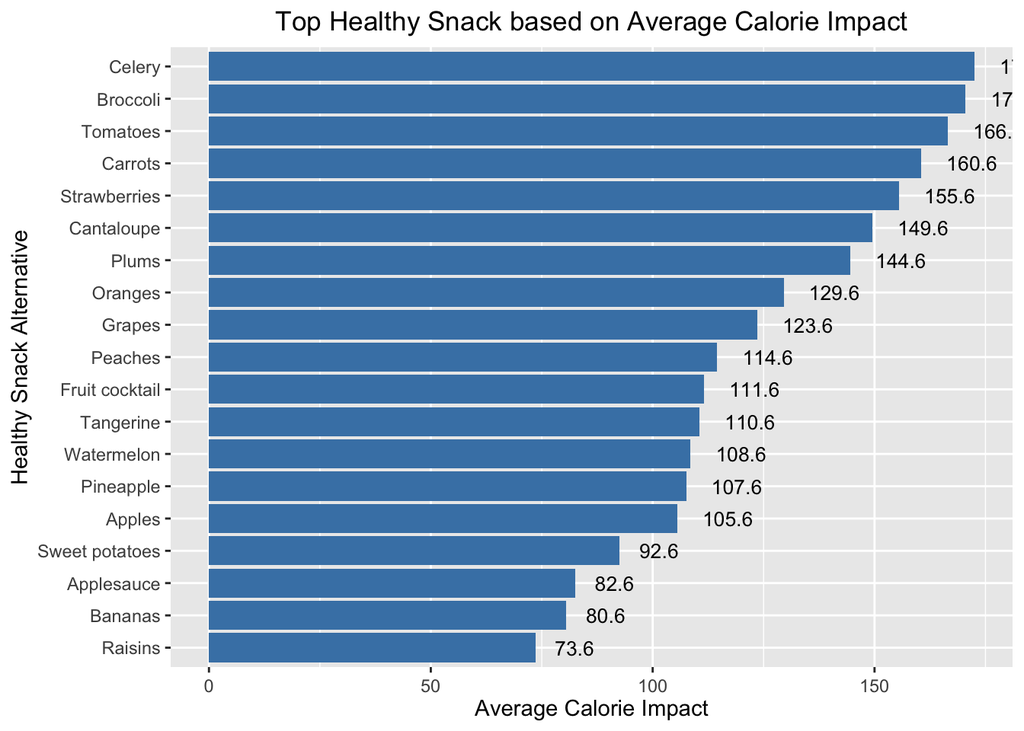

```r
#Healthy Snack Average Caloire impact
healthy_snack_DF <- snackDataframe %>% group_by(Healthy_Alternative) %>% summarise(Avg_Cal_Impact = mean(Calories),Total_Cost_impact = sum(Cost))

ggplot(healthy_snack_DF, aes(x = reorder(Healthy_Alternative,Avg_Cal_Impact), y = Avg_Cal_Impact)) +
  geom_bar(stat = "identity", position = "dodge", fill = "steelblue") +
  geom_text(aes(label=round(Avg_Cal_Impact,1)), hjust=-0.5, color="black", position = position_dodge(0.9), size=3.5) +
  scale_fill_brewer(palette="Paired") +
  theme(axis.text.x=element_text(angle = 0, vjust = 0.5)) +
  theme(plot.title = element_text(hjust = 0.5)) +
  ggtitle("Top Healthy Snack based on Average Calorie Impact") +
  xlab("Healthy Snack Alternative") +  ylab ("Average Calorie Impact") +
  coord_flip()
```

##### **Healthy Snack: Total Cost impact**

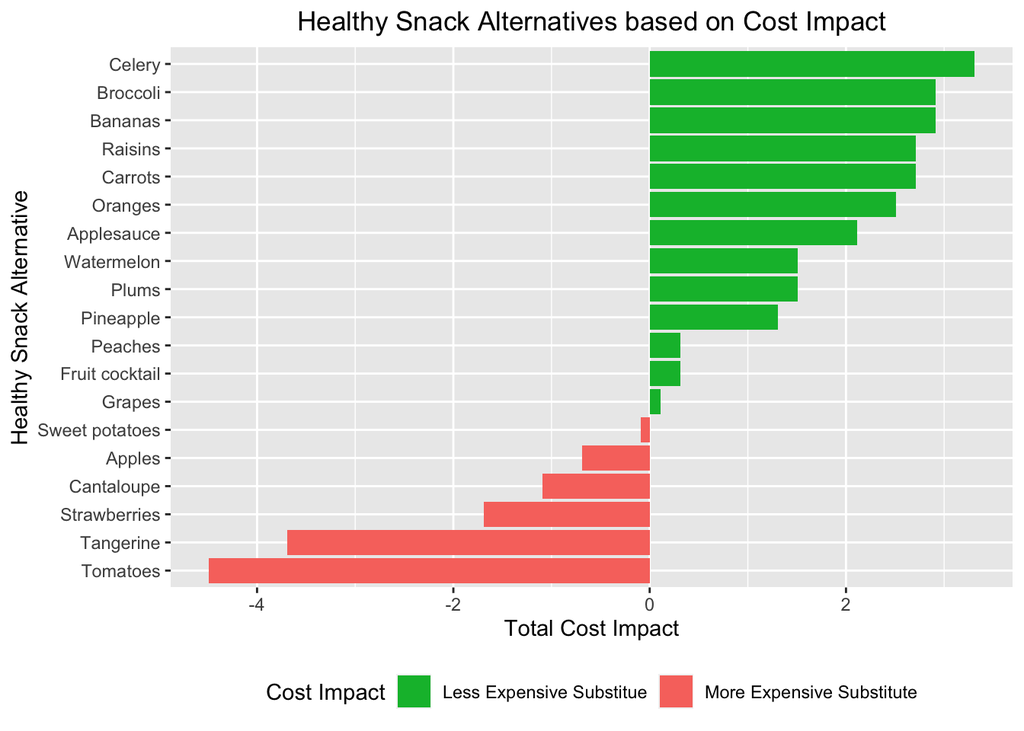

```r
# Derive a Cost Impact indicator variable
healthy_snack_DF$Cost = ifelse(healthy_snack_DF$Total_Cost_impact >= 0, "above", "below")

ggplot(healthy_snack_DF, aes(x = reorder(Healthy_Alternative,Total_Cost_impact), y = Total_Cost_impact)) +
  geom_bar(stat = "identity", position = "dodge",aes(fill = Cost)) +
  scale_fill_manual(name="Cost Impact",
                    labels = c("Less Expensive Substitue", "More Expensive Substitute"),
                    values = c("above"="#00ba38", "below"="#f8766d")) +
  ggtitle("Healthy Snack Alternatives based on Cost Impact") +
  theme(plot.title = element_text(hjust = 0.5),legend.position = "bottom") +
  xlab("Healthy Snack Alternative") +  ylab ("Total Cost Impact") +
  coord_flip()
```